# Where Myanmar’s War Clusters, and Where It Is Spreading

Local spatial association and emerging hot spots of armed conflict, January 2021 to September 2025

ZeXin Chen

25 October 2026

## Contents

**Part 1, The Question and the Data**

- Where Myanmar’s war is fought
- How the analysis works

**Part 2, Local Spatial Association**

- Insight 1, one hot core and its edges

**Part 3, Emerging Hot Spots**

- Insight 2, the core stayed hot and conflict spread around it
- Insight 3, each type of violence moves in a different direction
- Insight 4, air strikes grew where ground fighting grew

**Part 4, Bonus**

- Insight 5, when fighting leaves, other violence stays

**Part 5, So What**

- Key findings and limits
- Public-safety implications, by conflict region

## Since the coup, 43% of Myanmar’s armed conflict has been in one zone

Part 1 · The question and the data

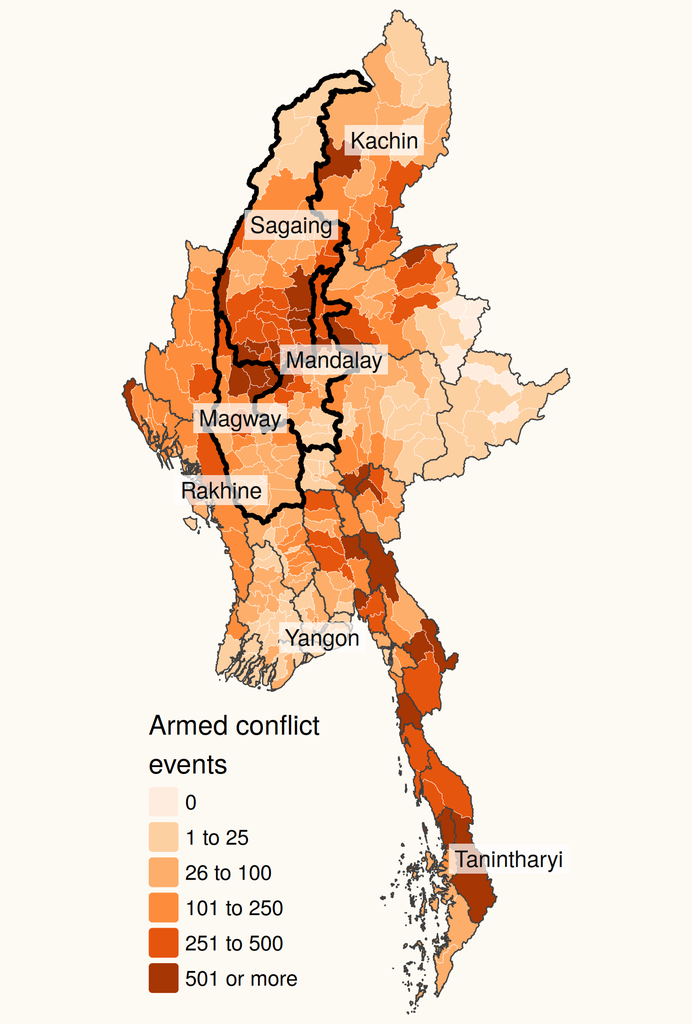

Research question

Where does armed conflict in Myanmar cluster, and how have these clusters changed since the 2021 coup?

54,000

armed conflict events, January 2021 to September 2025

4,034

events in Q4 2023, the peak, as Operation 1027 began

**Study area.** All 330 townships of Myanmar. Black outline, the Dry Zone of Sagaing, Magway and Mandalay.

**Data.** ACLED battles, explosions and remote violence, and violence against civilians, with MIMU township boundaries, counted by township and quarter.

## Clear the data land mines, then test every map against chance

Part 1 · The question and the data

Three land mines that would have misled the analysis

**6 rows were not in Myanmar.** Incidents off India and Sri Lanka filed under “Indian Ocean”. Removed first.

**One label hid two sides.** “Air/drone strike” mixes military aircraft and resistance drones. Split by actor.

**A software bug.** sfdep’s EHSA gives results to the wrong township unless the map is sorted by code. Sorted and checked.

| Step | Question | Method | Compared with |
| --- | --- | --- | --- |
| **Task 2** | Where does conflict cluster? Which stand out? | Local Moran’s I, Gi* | 999 shuffles |
| **Task 3** | Where are hot spots emerging or fading? | Mann-Kendall, EHSA, 19 quarters | No trend |
| **Bonus 1** | Do neighbours face the same *kind* of violence? | Multivariate local Geary’s c | 999 shuffles |
| **Bonus 2** | Which townships share a conflict timeline? | SKATER on Gi* paths | Ward, no geography |

Each township is compared with its 8 nearest neighbours, as the Lesson 5 notes advise for skewed counts and very uneven township sizes. Only p < 0.05 is mapped. Every result is checked for false alarms and with a second neighbour rule.

## Insight 1. One hot block in the Dry Zone, and no busy township stands alone

Part 2 · Local spatial association

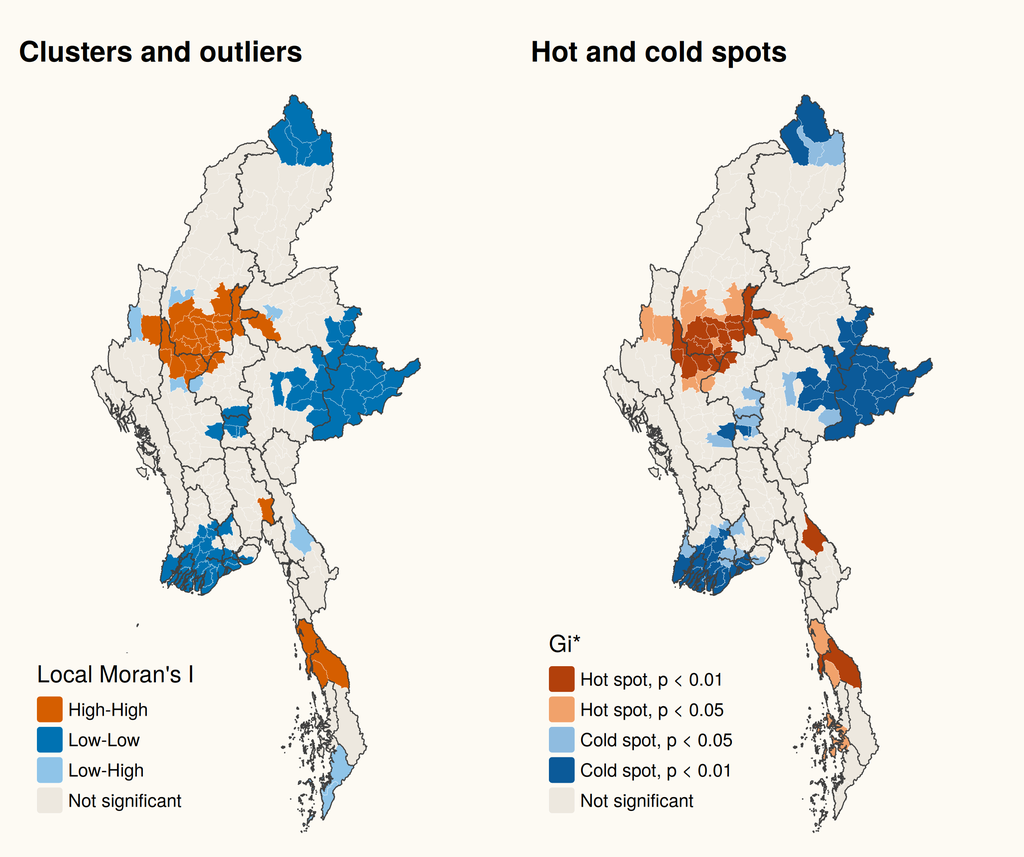

40

hot spot townships

31%

of all events fall in them

**One core.** 28 of 35 High-High townships form one block in Sagaing, Magway and Mandalay.

**Cold areas.** Yangon, the Ayeyarwady delta and eastern Shan.

The High-High core holds after FDR correction and with queen contiguity. Outliers are less stable. Busy Kawkareik is in no cluster, because its neighbours are quiet.

## Insight 2. The core stayed hot, and new hot spots appeared around it

Part 3 · Emerging hot spots

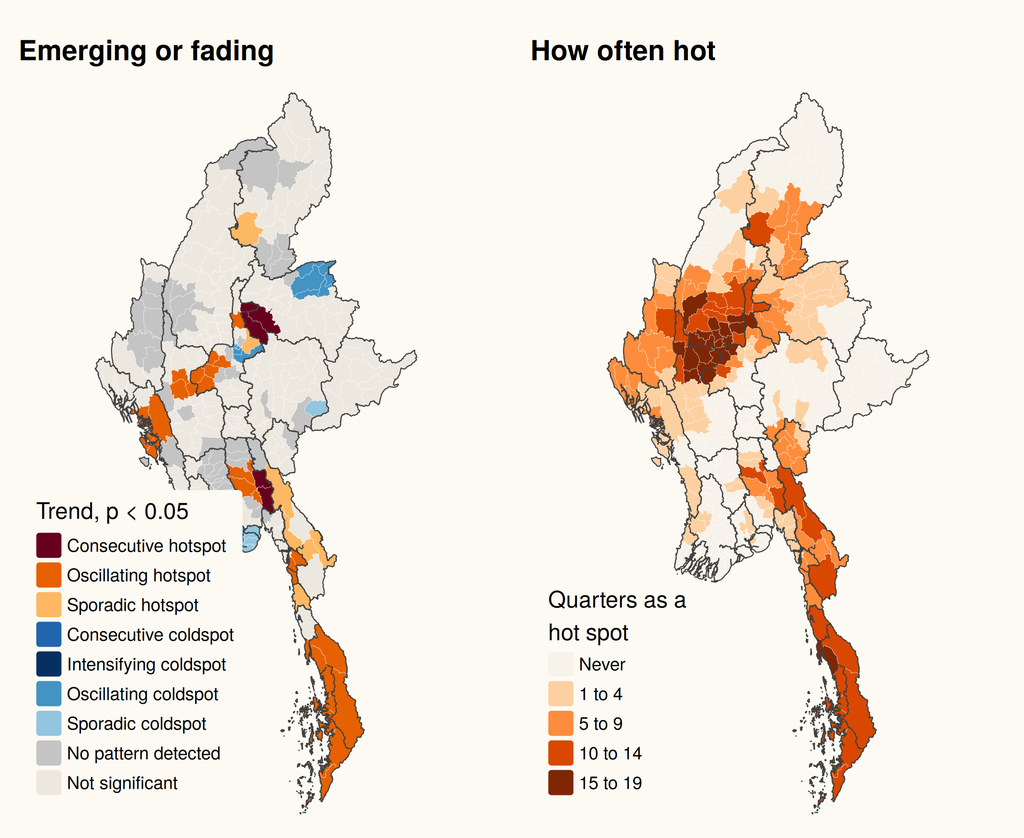

**The core stayed hot.** Sagaing’s core was a hot spot in 10 to 18 of 19 quarters. With no trend, the brief’s filter leaves it blank, so the right map shows it.

**New fronts.** 5 townships turned hot and stayed hot, in the hills of Bago East and on the road to northern Shan.

**Cold to hot.** 29 more, across Tanintharyi, Mon, central Rakhine, Bago East and the southern Dry Zone.

**Cooling.** 42 of Yangon’s 45 townships, and the northern Shan border after the 2024 ceasefire.

## Insight 3. Each type of violence is moving in a different direction

Part 3 · Emerging hot spots

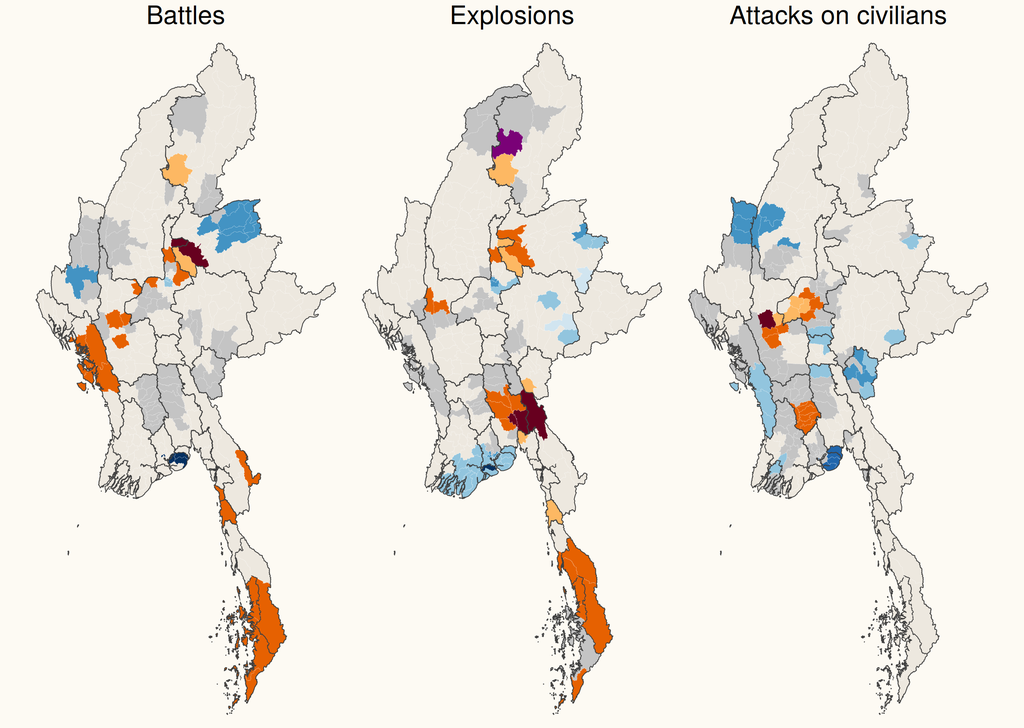

*■* New hotspot *■* Consecutive hotspot *■* Oscillating hotspot *■* Sporadic hotspot *■* Consecutive coldspot *■* Intensifying coldspot *■* Diminishing coldspot *■* Oscillating coldspot *■* Sporadic coldspot *■* No pattern detected *■* Not significant

**Battles moved south and west.** Tanintharyi and central Rakhine turned hot. Northern Shan went cold after the ceasefire.

**Explosions spread to the hills.** Bago East and Tanintharyi turned hot. Yangon’s bombings faded.

**Attacks on civilians moved to the lowlands.** 7 townships in Bago West turned hot, an area of little fighting.

## Insight 4. Military air strikes rose 23-fold, most where ground fighting grew

Part 3 · Emerging hot spots

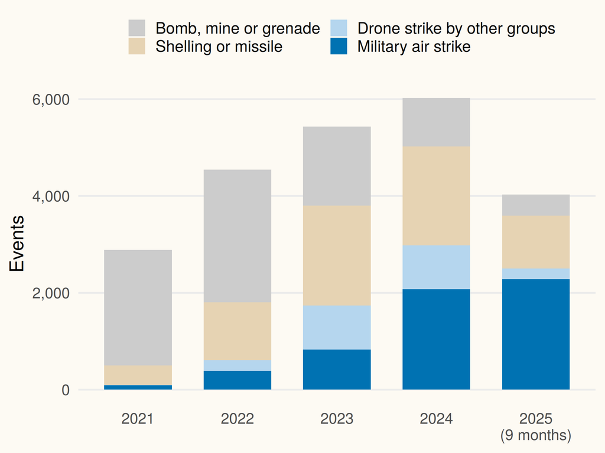

Explosions and remote violence by kind. Military air strikes kept climbing while resistance drone strikes peaked in 2023 and 2024.

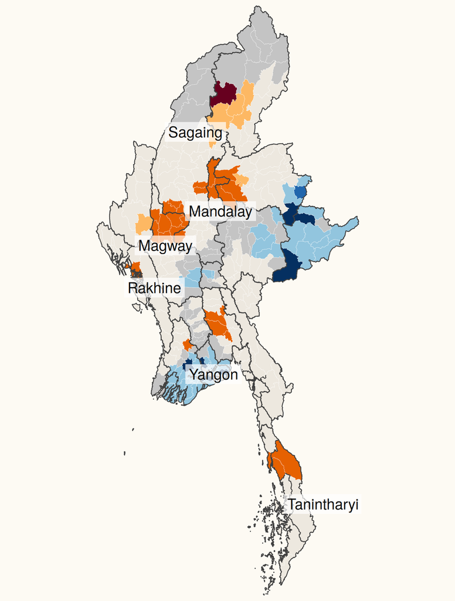

*■* Consecutive hotspot *■* Oscillating hotspot *■* Sporadic hotspot *■* Consecutive coldspot *■* Intensifying coldspot *■* Sporadic coldspot *■* No pattern detected *■* Not significant

## Insight 5. When fighting leaves, bombs and attacks on civilians often stay

Part 4 · Bonus, multivariate local Geary’s c

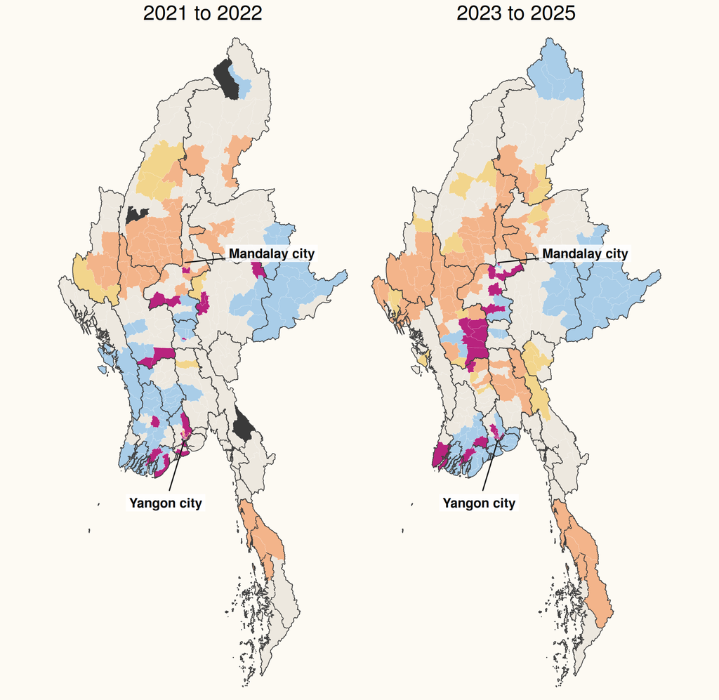

*■* **Few battles, more bombs or attacks on civilians** *■* All three high *■* Mostly battles *■* All three low *■* Mix unlike its neighbours

34

townships share a mix of few battles but many bombs or attacks on civilians

0

of them sit in a High-High cluster, so count maps call them quiet

**Why Geary’s c.** Listed in Lesson 5 under other forms of LISA. It compares a township’s whole mix of the three types with its neighbours’.

**What changed.** Around Mandalay, townships with all three types high in 2021 to 2022 had this mix by 2023 to 2025. Battles stopped, but bombs and attacks on civilians did not. In Yangon the group moved from downtown to the outskirts.

Assumptions. Counts are logged and standardised, and the types weigh the same. Limit. The urban group rests on tens of events per township. It holds with 6 or 10 neighbours.

## Key findings and their limits

Part 5 · So what

|  | Finding | Evidence | Main limit |
| --- | --- | --- | --- |
| **1** | The Dry Zone is the hot core | 43% of events, 28 of 35 High-High, hot in 10 to 18 of 19 quarters | Counts, not rates, since no reliable population data exists for 2021 to 2025 |
| **2** | Conflict spread out from the core | 5 consecutive and 29 oscillating hot spots ring the core. Conflict regions show the order, core first, south-east and Rakhine later | ACLED records reported events, so places with less access may look calmer |
| **3** | Yangon and northern Shan cooled | 42 of 45 Yangon townships in a cold pattern. Northern Shan cold after the 2024 ceasefire | A falling Gi* means a smaller share of the conflict, not peace |
| **4** | Each type moves in a different direction | Battles to Rakhine and Tanintharyi, explosions to Bago East, attacks on civilians to Bago West | Battle trends are weak. About half fail the FDR check |
| **5** | Air strikes grew most where ground fighting grew | About 23-fold rise, air hot spots in the core and on new fronts | Strikes are counted, not their harm |
| **6** | Bombs and attacks on civilians stay when fighting leaves | 34 townships share a bombs-and-civilians mix, growing around Mandalay | Rests on small counts per township |

**Main finding.** Where conflict is, where it clusters and where it is growing are three different questions. The core stayed in the Dry Zone while conflict spread around it.

## Public-safety implications, by conflict region

Part 5 · So what

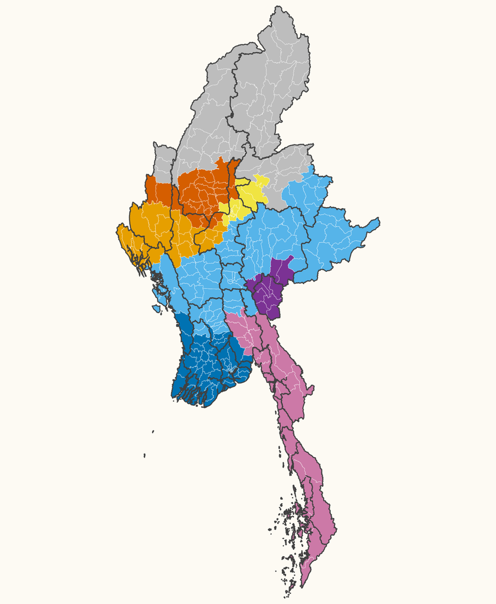

*■* Sagaing core *■* Rakhine, W. Dry Zone *■* Kayah *■* South-east frontier *■* Mandalay to N. Shan road *■* Northern borderlands *■* Central belt *■* Yangon and the delta

SKATER clustering from Lesson 6 groups neighbouring townships whose conflict rose and fell together into eight regions, each needing a different stance.

**Sagaing core. Plan long-term support**

Becausehot since late 2021, peaking in 2023 and still hot

Check firstdisplacement and access data from UN agencies and local partners

**South-east frontier. Early warning**

Becauseit rose slowly from 2022 and was at its highest in the last quarter

Check firstwhether local partners see the same spread, and which roads are open

**Kayah, and Rakhine with the western Dry Zone. Watch for relapse**

BecauseKayah peaked in 2022 and 2023, Rakhine in early 2024, and both have eased

Check firstwhether local ceasefires and front lines still hold

**Across regions. Protect civilians where fighting has moved on**

Becauseair strikes keep returning to the core and new fronts, and bombs and attacks on civilians stay in Yangon and Mandalay city

Check firstcasualty records, and under-reporting in tightly controlled cities

The analysis shows where and when, not why or who is responsible.

## References

1. ACLED (2024). *Between cooperation and competition: The struggle of resistance groups in Myanmar*.
2. Anselin, L. (1995). Local indicators of spatial association, LISA. *Geographical Analysis*, 27(2), 93 to 115.
3. Anselin, L. (2019). A local indicator of multivariate spatial association, extending Geary’s c. *Geographical Analysis*, 51(2), 133 to 150.
4. Assunção, R. M., Neves, M. C., Câmara, G. and da Costa Freitas, C. (2006). Efficient regionalization techniques for socio-economic geographical units using minimum spanning trees. *International Journal of Geographical Information Science*, 20(7), 797 to 810.
5. CFR (2025). *Civil War in Myanmar*. Global Conflict Tracker, Council on Foreign Relations.
6. Getis, A. and Ord, J. K. (1992). The analysis of spatial association by use of distance statistics. *Geographical Analysis*, 24(3), 189 to 206.
7. Hamed, K. H. and Rao, A. R. (1998). A modified Mann-Kendall trend test for autocorrelated data. *Journal of Hydrology*, 204, 182 to 196.
8. Kam, T. S. (2026). *R for Geospatial Data Science and Analytics*. https://r4gdsa.netlify.app/
9. Parry, J. (2023). *Emerging hot spot analysis*. sfdep package documentation.
10. Raleigh, C., Linke, A., Hegre, H. and Karlsen, J. (2010). Introducing ACLED, an armed conflict location and event dataset. *Journal of Peace Research*, 47(5), 651 to 660.

Data from ACLED and MIMU. Full code, checks and workflow in the Technical Report.